# golem shiny app-packages

Building a production-grade shiny app: whole-game

shiny

golem

packages

Author

Martin Frigaard

Published

June 1, 2023

This post walks through building a shiny application using the [`golem` framework](https://thinkr-open.github.io/golem/). `golem` is a ’*an opinionated framework for building production-grade shiny applications’*–I’ll explore some of the opinions (and offer my opinion on adopting these opinions).

**Important**Highly recommend**

I highly recommend this.

**Caution**Recommend**

I recommend adopting this practice (or something very similar).

**Note**Useful**

This practice is useful, but maybe not for all applications.

**Tip**Tip**

Additional notes or thoughts on an opinion or practice.

```r
install.packages("devtools")
devtools::install_github("mjfrigaard/gap")
```

For consistency, I’ll be using the application from the RStudio’s [Building Web Applications with Shiny](https://rstudio-education.github.io/shiny-course/) course. These materials are a great resource if you’re new to shiny–even if you’re aren’t, it’s still worth checking out–plus it’s free!

The [golem text](https://engineering-shiny.org/) is also a fantastic resource, but I found myself using the [`golem` website](https://thinkr-open.github.io/golem/) as a great ‘quick reference.’ If you’re unfamiliar with R package development, I recommend bookmarking [R packages](https://r-pkgs.org/)–this is a great resource you’ll return to often.

[figure not shown]

## Outline

I’ve organized the app-package development process into three areas: **Start**, **Build**, and **Use**.

- **Start** covers the required steps to launch your `golem` project in the RStudio IDE, common R package files and folders, and other setup considerations.
- **Build** covers the app-package development process, which includes writing and storing code, data, external resources (like CSS or JavaScript), testing, etc.
- **Use** shows how to launch a `golem` application locally (i.e., within the RStudio IDE), common workflow tips, and anything I found confusing while building the application.

### `dev/` scripts

New `golem` apps automatically open the `01_start.R` script from the `dev/` folder. This is the first of three .R scripts that serve as a ‘guided tour’ of the `golem` framework (`01_start.R`, `02_dev.R`, and `03_deploy.R`):

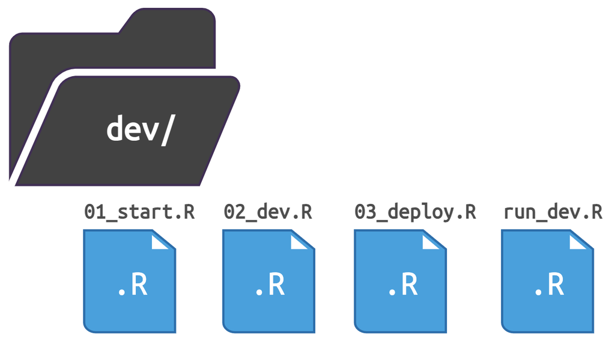

golem `dev/` scripts

The `run_dev.R` is also in the `dev/` folder, but it’s for running a development version of your app (more on this later).

**NoteDevelopment scripts: **Note**

If you’re familiar with R application development, you should recognize most of the items in the `dev/` scripts. I recommend going through these scripts even if you’re an experienced R package developer–you can think of these as a ‘shiny app-package development checklist.’

## Start

To create a new `golem` app from the console, enter the following:

```r
install.packages("golem")
library(golem)
golem::create_golem(path = "gap")
```

If you’re creating a `golem` app using the **New Project Wizard**, the following defaults are available:

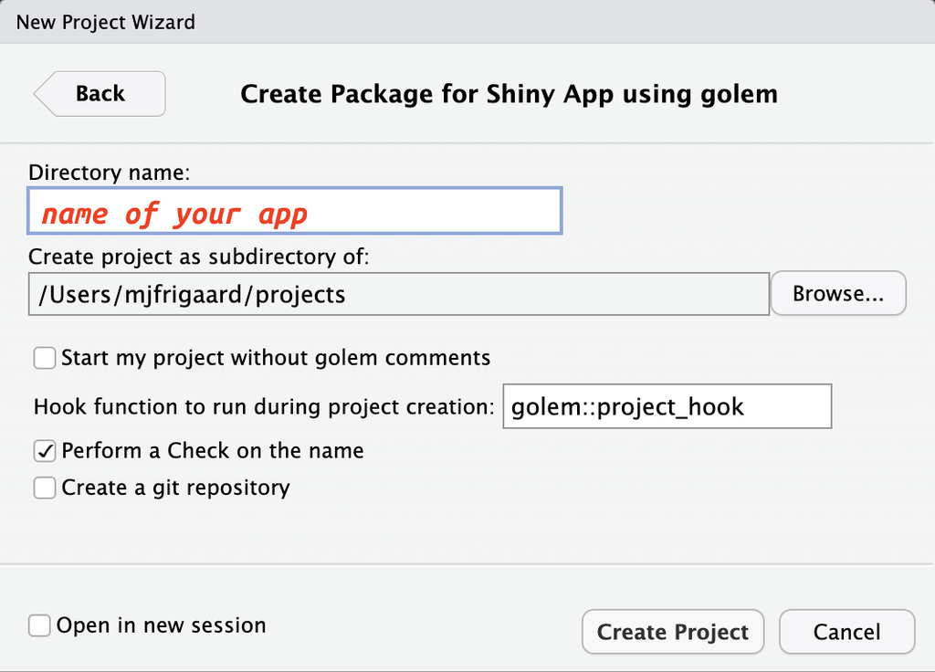

IDE wizard `golem` setup

Figure 1: Creating a new `golem` shiny app

**Important`golem` comments: **Highly recommend**

I recommend using `golem` comments–they’re helpful and don’t change how the application code runs.

When the new project opens, the initial folder structure for your new `golem` application is below:

**show/hide golem folder structure**

```bash
app-name/
  ├── DESCRIPTION
  ├── NAMESPACE
  ├── R
  │   ├── app_config.R
  │   ├── app_server.R
  │   ├── app_ui.R
  │   └── run_app.R
  ├── dev
  │   ├── 01_start.R
  │   ├── 02_dev.R
  │   ├── 03_deploy.R
  │   └── run_dev.R
  ├── [app-name].Rproj
  ├── inst
  │   ├── app
  │   │   └── www
  │   │       └── favicon.ico
  │   └── golem-config.yml
  └── man
      └── run_app.Rd

  7 directories, 14 files
```

### Begin `01_start.R`

The `dev/01_start.R` file is covered in the first few sections of the [`golem` text](https://engineering-shiny.org/golem.html), but I prefer the [package website](https://thinkr-open.github.io/golem/articles/a_start.html) as a reference because it walks through each `dev/` script (with links to the `golem` functions).

#### `Fill` `the` `DESCRIPTION`

**Important`golem::fill_desc()`: **Highly recommend**

The `DESCRIPTION` file plays and important role in R packages (probably why it’s the first item in the `01_start.R` file).

> ‘*all a project needs to be a package is a directory of `R/` files and a `DESCRIPTION` file.*’ - [Packages Chapter of Mastering Shiny](https://mastering-shiny.org/scaling-packaging.html#summary-18)

The `golem::fill_desc()` arguments are a great way to guarantee your `DESCRIPTION` file is set up correctly.

There are three files in a new golem app-package–`NAMESPACE`, `DESCRIPTION`, and `[app name].Rproj`. `dev/01_start.R` starts by building the `DESCRIPTION` file with [`golem::fill_desc()`](https://thinkr-open.github.io/golem/reference/fill_desc.html)

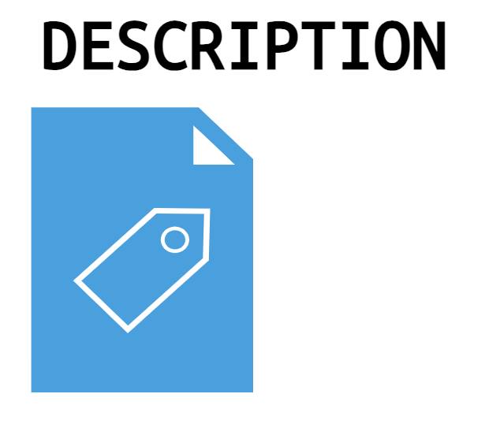

golem `DESCRIPTION`

`fill_desc()` is from the [`desc` package](https://r-lib.github.io/desc/), and the sections are entered in a `key = "value"` format

- Example `DESCRIPTION` file contents:

  ```r
  golem::fill_desc(
    pkg_name = "gap",
    pkg_title = "An example goelm app",
    pkg_description = "A working example of the golem package.",
    author_first_name = "Martin",
    author_last_name = "Frigaard",
    author_email = "mjfrigaard@pm.me",
    repo_url = NULL # The URL of the GitHub Repo (optional)
  )
  ```

  **show/hide output from golem::fill_desc()**

  ```bash
  ✔ Setting `golem_version` to 0.0.0.9000
  ✔ Setting `golem_name` to gap
  ✔ DESCRIPTION file modified
  ```

**TipWhat if I need to edit the `DESCRIPTION`?**

In `dev/02_dev.R`, `attachment::att_amend_desc()` will ‘*Amend `DESCRIPTION` with dependencies read from package code parsing*’. If `attachment` is not installed, use `install.package('attachment')`

#### `Set` `{golem}` `options`

The `golem::set_golem_options()` wraps a collection of `golem`‘s ’opinionated’ application development and configuration options.

```r
golem::set_golem_options()
```

**show/hide output from golem::set_golem_options()**

```bash
── Setting {golem} options in `golem-config.yml` ────────────────────────────────────────────────────────────────────
✔ Setting `golem_name` to gap
✔ Setting `golem_wd` to golem::pkg_path()
You can change golem working directory with set_golem_wd('path/to/wd')
✔ Setting `golem_version` to 0.0.0.9000
✔ Setting `app_prod` to FALSE
── Setting {usethis} project as `golem_wd` ──────────────────────────────────────────────────────────────────────────
✔ Setting active project to '/projects/gap'
```

`set_golem_options()` is a wrapper for a collection of `golem` option functions (I’ve included each function and a brief description of their behavior below):

**show/hide golem options**

```r
golem::set_golem_options(
  golem_name = golem::pkg_name(), # name of the app-package in DESCRIPTION
  golem_version = golem::pkg_version(), # version in DESCRIPTION
  golem_wd = golem::pkg_path(), # package root when starting a golem
  app_prod = FALSE, # production mode?
  talkative = TRUE, # Should the messages be printed to the console?
  config_file = golem::get_current_config(golem_wd) # golem-config.yml location
)
```

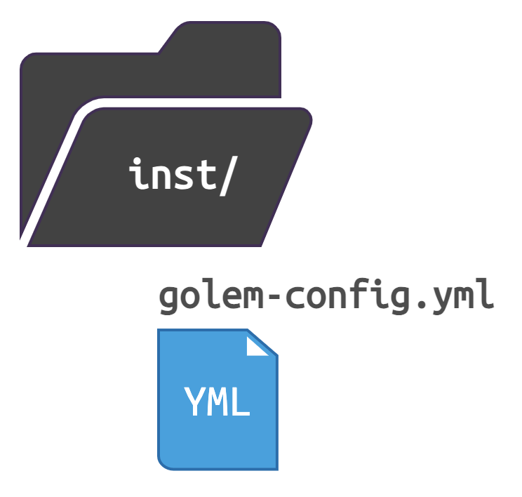

golem config file

The new config file is located in the `inst/` folder.

**Important`golem::set_golem_options()`: **Highly recommend**

To fully understand the `golem` framework, I recommended running this function. The functions called for each argument in `golem::set_golem_options()` provide some insight into how a `golem` app is structured (i.e., where the `name` and `version` information is stored, the location of the root directory, etc.)

#### `Install` `required` `dev` `dependencies`

The `golem::install_dev_deps()` function makes sure the following packages are installed (I’ve grouped them into categories):

##### Development

- [`devtools`](https://devtools.r-lib.org/) (loading, documenting, installing package)
  - [`pkgload`](https://pkgload.r-lib.org/) (i.e., `devtools::load_all()`)
- [`usethis`](https://usethis.r-lib.org/) (create package files)
- [`roxygen2`](https://roxygen2.r-lib.org/) (document package functions and objects)
- [`pkgbuild`](https://pkgbuild.r-lib.org/) (create a `.tar.gz` file)

##### Documentation & testing

- [`attachment`](https://thinkr-open.github.io/attachment/) (deal with package dependencies)
- [`desc`](https://desc.r-lib.org/) (Parse `DESCRIPTION` files)
- [`testthat`](https://testthat.r-lib.org/) (unit testing your code)

##### Internals

- [`rstudioapi`](https://rstudio.github.io/rstudioapi/) (interacting with RStudio IDE)
- [`processx`](https://processx.r-lib.org/) (execute and control subprocesses from R)

##### Files & paths

- [`here`](https://here.r-lib.org/) (file/folder path management)
- [`fs`](https://fs.r-lib.org/) (file/folder path management)

##### Deploy

- [`dockerfiler`](https://github.com/ThinkR-open/dockerfiler) (deploying apps with docker)
- [`rsconnect`](https://rstudio.github.io/rsconnect/) (deploy shiny apps with RSConnect)

```r
golem::install_dev_deps()
```

Below is an example with `dockerfiler`:

**show/hide output from golem::install_dev_deps()**

```bash
ℹ The package "dockerfiler" is required.
✖ Would you like to install it?

1: Yes
2: No

Selection: 1
✔ Updated metadata database: 5.32 MB in 12 files.
✔ Updating metadata database ... done

→ Will install 1 package.
→ Will download 1 CRAN package (104.29 kB).
+ dockerfiler   0.2.1  ⬇ (104.29 kB)
ℹ Getting 1 pkg (104.29 kB)
✔ Got dockerfiler 0.2.1 (x86_64-apple-darwin17.0) (104.29 kB)
✔ Downloaded 1 package (104.29 kB)in 1.1s
✔ Installed dockerfiler 0.2.1  (54ms)
✔ 1 pkg + 40 deps: kept 40, added 1, dld 1 (104.29 kB) [20.2s]
```

**Important`golem::install_dev_deps()`: **Highly recommned**

I recommend using `golem`’s options here–it’s efficient and let’s you know if a particular package isn’t installed:

#### `Create` `Common` `Files`

The ‘Create Common Files’ section of `dev/01_start.R` contains many of the functions and files covered in the [‘Whole Game’ section of R packages](https://r-pkgs.org/whole-game.html):

- **LICENSE**

  ```r
  usethis::use_mit_license("Golem User")
  ```

  ```bash
  ✔ Adding 'MIT + file LICENSE' to License
  ✔ Writing 'LICENSE'
  ✔ Writing 'LICENSE.md'
  ✔ Adding '^LICENSE\\.md$' to '.Rbuildignore'
  ```

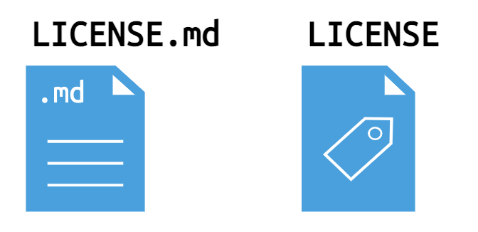

golem `LICENSE` file

- **README.Rmd**

  ```r
  usethis::use_readme_rmd()
  ```

  ```bash
  ✔ Writing 'README.Rmd'
  ✔ Adding '^README\\.Rmd$' to '.Rbuildignore'
  • Update 'README.Rmd' to include installation instructions.
  ```

  - The **README.md** is built with `devtools::build_readme()`

    ```r
    devtools::build_readme()
    ```

    ```bash
    ℹ Installing gap in temporary library
    ℹ Building /projects/gap/README.Rmd
    ```

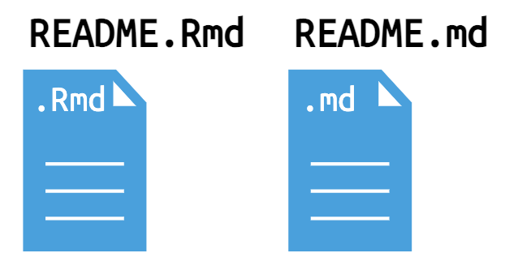

golem README.Rmd file

- **CODE_OF_CONDUCT.md**

  ```r
  usethis::use_code_of_conduct()
  ```

  ```bash
  ✔ Writing 'CODE_OF_CONDUCT.md'
  ✔ Adding '^CODE_OF_CONDUCT\\.md$' to '.Rbuildignore'
  • You may also want to describe the code of conduct in your README:
    ## Code of Conduct

  Please note that the gap project is released with a [Contributor Code of
      Conduct](https://contributor-covenant.org/version/2/1/CODE_OF_CONDUCT.html).
  By contributing to this project, you agree to abide by its terms.
    [Copied to clipboard]
  ```

  - Paste of the code of conduct in the **README.md** is rebuild with `devtools::build_readme()`

    ```r
    devtools::build_readme()
    ```

    ```bash
    ℹ Installing gap in temporary library
    ℹ Building /projects/gap/README.Rmd
    ```

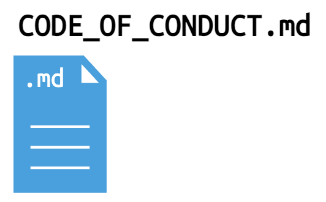

golem code of conduct file

- **Lifecycle badge**

  ```r
  usethis::use_lifecycle_badge("Experimental")
  ```

  ```bash
  ✔ Adding Lifecycle: experimental badge to 'README.Rmd'
  • Re-knit 'README.Rmd' with `devtools::build_readme()`
  ```

  - Rebuild the **README.md** with `devtools::build_readme()`

    ```bash
    ℹ Installing gap in temporary library
    ℹ Building /projects/gap/README.Rmd
    ```

[figure not shown]

`golem` lifecycle badge

- **NEWS.md**

  ```r
  usethis::use_news_md(open = FALSE)
  ```

  ```bash
  ✔ Writing 'NEWS.md'
  ```

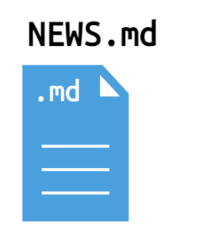

golem `NEWS.md` file

- **Git**: `usethis::use_git()` will ask if you’d like to commit the files in your golem app to a repo of the same name:

  ```r
  usethis::use_git()
  ```

  ```bash
  ✔ Setting active project to '/projects/gap'
  ✔ Initialising Git repo
  ✔ Adding '.Rproj.user', '.Rhistory', '.Rdata', '.httr-oauth',
    '.DS_Store', '.quarto' to '.gitignore'
  There are 16 uncommitted files:
  * '.gitignore'
  * '.here'
  * '.Rbuildignore'
  * 'CODE_OF_CONDUCT.md'
  * 'DESCRIPTION'
  * 'dev/'
  * 'gap.Rproj'
  * 'inst/'
  * 'LICENSE'
  * 'LICENSE.md'
  * ...
  Is it ok to commit them?

  1: Definitely
  2: Negative
  3: Not now

  Selection: 1
  ```

  - To initialize the Git pane, you’ll need to restart RStudio (in the next dialogue)

    ```bash
    ✔ Adding files
    ✔ Making a commit with message 'Initial commit'
    • A restart of RStudio is required to activate the Git pane
    Restart now?

    1: Absolutely
    2: Negative
    3: No
    Selection: 1
    ```

**CautionCommon files: **Recommend**

Each of these files are important for an R package, so having them consolidated in `01_start.R` makes it easier to get up and running quickly. However, if you’d like to edit their contents before moving onto the next step (or you’d like information on a particular function/file), I recommend consulting [R packages](https://r-pkgs.org/whole-game.html) for this section

#### `Init` `Testing` `Infrastructure`

`golem::use_recommended_tests()` with set up the `testthat` architecture for unit tests.

```r
golem::use_recommended_tests()
```

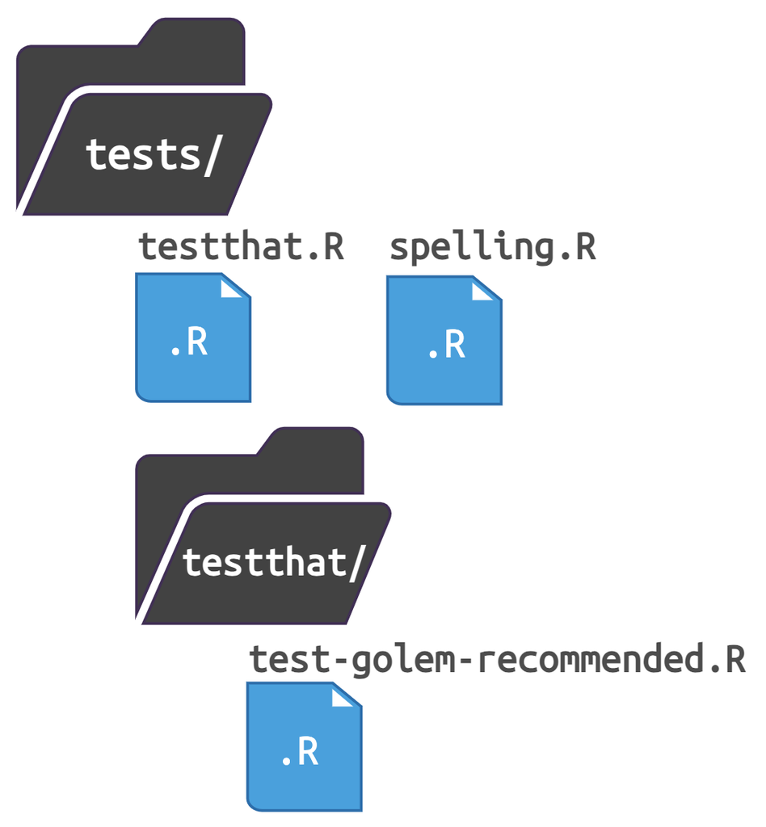

golem test files

```bash
✔ Setting active project to '/projects/gap'
✔ Adding 'testthat' to Suggests field in DESCRIPTION
✔ Adding '3' to Config/testthat/edition
✔ Creating 'tests/testthat/'
✔ Writing 'tests/testthat.R'
• Call `use_test()` to initialize a basic test file and open it for editing
```

It also adds a few words to the `WORDLIST` file in the `inst` folder:

```bash
✔ Adding 'spelling' to Suggests field in DESCRIPTION
✔ Adding 'en-US' to Language
The following words will be added to the wordlist:
 - Lifecycle
 - goelm
 - golem
Are you sure you want to update the wordlist?
1: Yes
2: No

Selection: 1
Added 3 and removed 0 words in /projects/gap/inst/WORDLIST
Updated /projects/gap/tests/spelling.R
• Run `devtools::check()` to trigger spell check
✔ Tests added
```

`golem::use_recommended_tests()` also provides some examples for testing the UI, server, and other `golem` functions:

**show/hide unit tests in test-golem-recommended.R**

```r
test_that("app ui", {
  ui <- app_ui()
  golem::expect_shinytaglist(ui)
  # Check that formals have not been removed
  fmls <- formals(app_ui)
  for (i in c("request")) {
    expect_true(i %in% names(fmls))
  }
})

test_that("app server", {
  server <- app_server
  expect_type(server, "closure")
  # Check that formals have not been removed
  fmls <- formals(app_server)
  for (i in c("input", "output", "session")) {
    expect_true(i %in% names(fmls))
  }
})

test_that(
  "app_sys works",
  {
    expect_true(
      app_sys("golem-config.yml") != ""
    )
  }
)

test_that(
  "golem-config works",
  {
    config_file <- app_sys("golem-config.yml")
    skip_if(config_file == "")

    expect_true(
      get_golem_config(
        "app_prod",
        config = "production",
        file = config_file
      )
    )
    expect_false(
      get_golem_config(
        "app_prod",
        config = "dev",
        file = config_file
      )
    )
  }
)

# Configure this test to fit your need.
# testServer() function makes it possible to test code in server functions and modules, without needing to run the full Shiny application
testServer(app_server, {

  # Set and test an input
  session$setInputs(x = 2)
  expect_equal(input$x, 2)

  # Example of tests you can do on the server:
  # - Checking reactiveValues
  # expect_equal(r$lg, 'EN')
  # - Checking output
  # expect_equal(output$txt, "Text")
})

# Configure this test to fit your need
test_that(
  "app launches",
  {
    golem::expect_running(sleep = 5)
  }
)
```

These tests pass right out of the box, and they give a little ‘sneak preview’ of how the `golem` framework works.

**show/hide results from unit tests in test-golem-recommended.R**

```bash
==> Testing R file using 'testthat'

ℹ Loading gap
[ FAIL 0 | WARN 0 | SKIP 0 | PASS 9 ]
Loading required package: shiny
[ FAIL 0 | WARN 0 | SKIP 1 | PASS 10 ]

── Skipped tests (1) ─────────
• interactive() is not TRUE
  (1):
  test-golem-recommended.R:72:5


Test complete
```

**Important`golem` recommended tests: **Highly recommend**

I love this feature of golem apps! in a single function I have the folders required for unit testing, words added to the WORDLIST (which I almost never remember to do), and an example test with shiny’s [`testServer()`](https://shiny.posit.co/r/reference/shiny/1.7.0/testserver) function.

#### `Favicon`

A [favicon](https://en.wikipedia.org/wiki/Favicon) is a the little image that shows up on your browser tab or address bar. `golem` has a default favicon in the `inst/app/` folder:

[figure not shown]

golem favicon file

```bash
inst/
  └── app
       └── www
            └── favicon.ico


3 directories, 1 file
```

The `inst/` folder serves a specific purpose in golem apps (and R packages), which I’ll cover more below. For our purpose, the `golem::use_favicon()` function can use the existing image:

```r
golem::use_favicon(path = "inst/app/www/favicon.ico")
```

The output introduces another common `golem` function: `golem_add_external_resources()`

```bash
✔ favicon.ico created at
/projects/gap/inst/app/www/favicon.ico
Favicon is automatically linked in app_ui via `golem_add_external_resources()`
```

This function is used to add external resources to your application (and will come up often during development).

#### `Add` `helper` `functions`

Most applications will have two types of code–`shiny` functions for running your application (app functions), and functions that do everything else (or utility functions). The `golem` framework further distinguishes utility functions into two types: **1)** *“small functions that are reused throughout the app”* (with a `utils_` prefix), and **2)** *“larger functions, which are more central to the application”* (with a `fct_` prefix).

**NoteDocumenting & exporting functions: **NOTE**

The functions in `golem_utils_ui.R` and `golem_utils_server.R` are created with the [`@noRd` tag](https://roxygen2.r-lib.org/articles/rd.html?q=@noRd#basics), which prevents the `.Rd` file generation. If you’d like the functions available outside of the package, you can use `@export`. If you’d like [‘a manual page created but not present in the function index’](https://roxygen2.r-lib.org/articles/rd-other.html#packages), use `@keywords internal`. See the examples I’ve created [here](https://github.com/mjfrigaard/gap/blob/main/R/golem_utils_ui.R) and [here](https://github.com/mjfrigaard/gap/blob/main/R/golem_utils_server.R)

The descriptions below are [from the text](https://engineering-shiny.org/build-app-golem.html?functions#submodules-and-utility-functions) and provide examples for the two types of utility functions:

> **`utils_` functions:** “*…the `hexmake` app has two of these files, `R/utils_ui.R` and `R/utils_server.R`, in which you will find small functions that are reused throughout the app.*”

> **`fct_` functions:** “*…in `hexmake`, you will find `R/fct_mongo.R`, which is used to handle all the things related to connecting and interacting with the Mongodb database.*”

##### `use_utils_ui()`

The `golem::use_utils_ui()` function will add a collection of utility functions for the UI. Including `with_test = TRUE` will add a test for these functions.

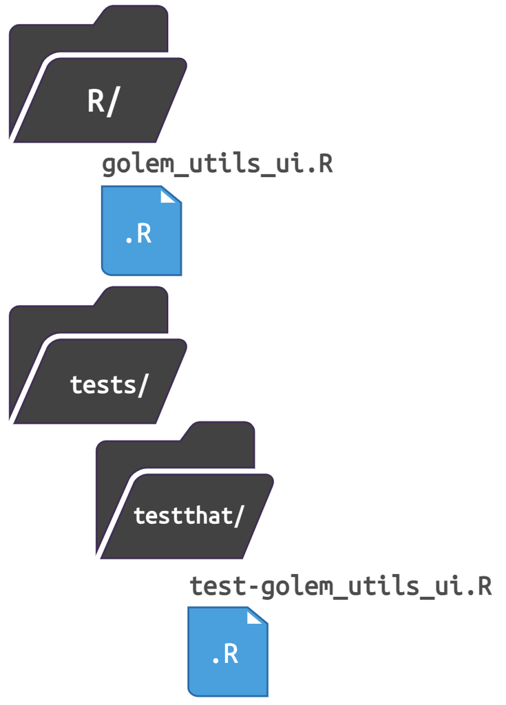

golem UI utility functions & tests

```r
golem::use_utils_ui(with_test = TRUE)
```

```bash
✔ File created at /projects/gap/R/golem_utils_ui.R
✔ Utils UI added
✔ File created at /projects/gap/tests/testthat/test-golem_utils_ui.R
✔ Tests on utils_server added
```

##### `use_utils_server()`

`golem` also includes a set of functions for the application server (or server modules), `golem::use_utils_server()`. The `with_test = TRUE` will also add a test to the `tests/testthat/` folder:

```r
golem::use_utils_server(with_test = TRUE)
```

```bash
✔ File created at /projects/gap/R/golem_utils_server.R
✔ Utils server added
✔ File created at /projects/gap/tests/testthat/test-golem_utils_server.R
✔ Tests on utils_server added
```

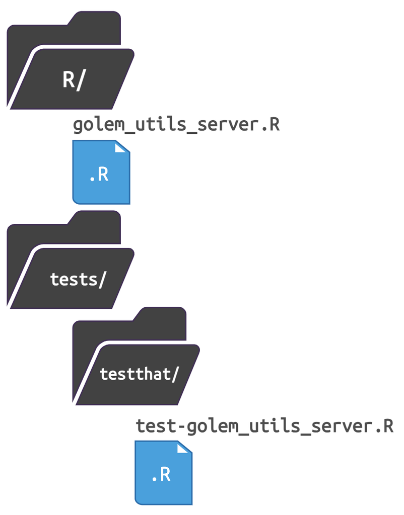

golem server utility functions & tests

**Caution`golem` utility functions: **Recommend**

I consider these functions optional, but the examples in each file have a broad enough application that you’ll probably discover something helpful for your `golem` application. The `with_test` argument also provides more examples of unit tests for your application functions, so you’re likely to find something useful!

### End `01_start.R`

This is the final function in the `dev/01_start.R` file. In the next `golem` dev script (`dev/02_dev.R`), I’ll cover development of your `golem` application.

## Build

The `dev/02_dev.R` file is appropriately titled, ‘`Engineering`’, and unlike the functions in the first script, these functions will be used repeatedly for creating files in the `R/` and `inst/` folders.

### Begin `02_dev.R`

#### App files

Let’s start by examining the [contents of the `R/` folder](https://engineering-shiny.org/golem.html#r) in our new `golem` application:

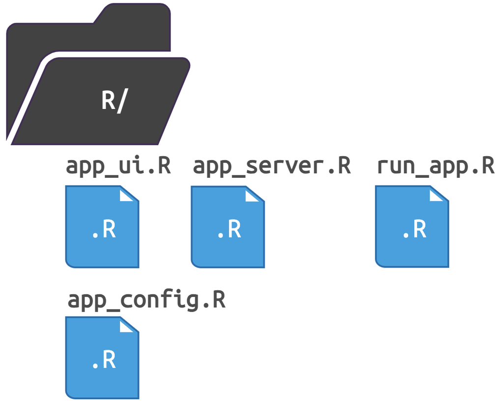

golem application files

```bash
R/
├── app_config.R
├── app_server.R
├── app_ui.R
└── run_app.R

1 directory, 4 files
```

- The `R/app_ui.R` and `R/app_server.R` scripts are `golem`’s version of `ui.R` and `server.R`
- `R/run_app.R` is a standalone app function, and
- `R/app_config.R` is used to set/get `golem` configuration settings (which we will cover more below).

##### `app_ui.R`

`app_ui.R` wraps the UI functions in `shiny::tagList()` (you’ll see this function in shiny UI module functions, too).

**show/hide app_ui()**

```r
app_ui <- function(request) {
  tagList(
    # Leave this function for adding external resources
    golem_add_external_resources(),
    # Your application UI logic
    fluidPage(
      h1("gap")
    )
  )
}
```

`app_ui()` also contains a call to `golem_add_external_resources()`, which we used above to add the favicon image.

**show/hide golem_add_external_resources()**

```r
golem_add_external_resources <- function() {
  add_resource_path(
    "www",
    app_sys("app/www")
  )

  tags$head(
    favicon(),
    bundle_resources(
      path = app_sys("app/www"),
      app_title = "gap"
    )
    # Add here other external resources
    # for example, you can add shinyalert::useShinyalert()
  )
}
```

##### `app_server.R`

The contents of `app_server.R` file looks similar to a standard shiny server function:

**show/hide app_server()**

```r
app_server <- function(input, output, session) {
  # Your application server logic
}
```

##### `app_config.R`

The `app_config.R` file contains the “*internal mechanics for `golem`, notably for referring to values in the `inst/` folder, and to get values from the `config` file in the `inst/` folder*”. Two functions drive the internal mechanics of your `golem` app: `app_sys()` and `get_golem_config()`

- `app_sys()` is a wrapper around the `system.file()` function, and it’s used to *“quickly refer to the files inside the `inst/` folder”*

**show/hide app_sys()**

```r
app_sys <- function(...) {
  system.file(..., package = "gap")
}
```

- `get_golem_config()` is where you’ll set `golem` configuration options (covered [here in the text](https://engineering-shiny.org/golem.html#manipulating-golem-config.yml)).

**show/hide get_golem_config()**

```r
get_golem_config <- function(
  value,
  config = Sys.getenv(
    "GOLEM_CONFIG_ACTIVE",
    Sys.getenv(
      "R_CONFIG_ACTIVE",
      "default"
    )
  ),
  use_parent = TRUE,
  # Modify this if your config file is somewhere else
  file = app_sys("golem-config.yml")
) {
  config::get(
    value = value,
    config = config,
    file = file,
    use_parent = use_parent
  )
}
```

`get_golem_config()` reads the `inst/golem-config.yml` configuration file:

```bash
default:
  golem_name: gap
  golem_version: 0.0.0.9000
  app_prod: no
production:
  app_prod: yes
dev:
  golem_wd: !expr here::here()
```

[`golem-config.yml`](https://engineering-shiny.org/golem.html#manipulating-golem-config.yml) gives me access to the app version, name, and (development) working directory. This file is designed to add “*production-only elements*” and be “*shareable across `golem` projects*”

##### `run_app.R`

`run_app.R` is the exported function I’ll use to run my `golem` app after loading/documenting/installing the package:

```r
devtools::load_all(".")
```

```bash
ℹ Loading gap
```

```r
devtools::document()
```

```bash
ℹ Updating gap documentation
ℹ Loading gap

Restarting R session...
```

```r
library(gap)
gap::run_app()
```

**Tip`R/app_config.R`: **Tip**

The great thing about `golem` applications is that despite having a somewhat overwhelming amount of code and options, most of these can be ignored until you need to use them. `R/app_config.R` is a great example of this. The `get_golem_config()` function is a powerful tool for deploying apps in production, but you can get started developing your application without diving into the details.

#### `Dependencies`

Dependency management is a necessary evil of package development. `shiny` has a large ecosystem of user-written add-on packages. To use the code from add-on packages in our application, we need a way to keep track of which function belongs to which package.

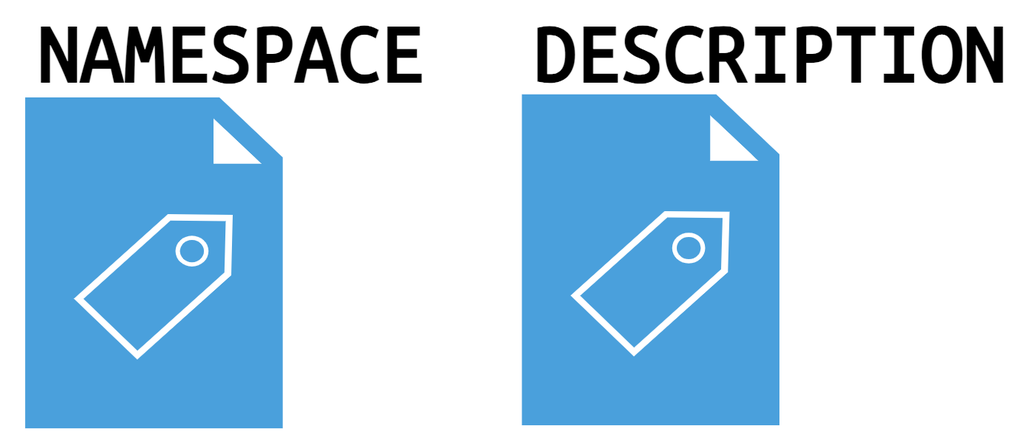

golem app dependencies

**The `DESCRIPTION` file manages package-level dependencies.** The `Imports` field in the `DESCRIPTION` file specifies packages that my package uses, so the functions from these packages will be available for my package, but not for users (unless they use the `::` operator or load the package themselves).

**The `NAMESPACE` file manages function-level access.** The `NAMESPACE` file manages the functions that are *exported* from my package (i.e., functions available to users who install my package), and the functions my package *imports* from other packages.

The `golem` text describes the difference between these files in the following way,

> “*The `DESCRIPTION` file dictates which packages have to be installed **when your application is installed***”

> “*The `NAMESPACE` file describes how your app interacts with the R session at run time, i.e. **when your application is launched***”

The [`attachment` package](https://thinkr-open.github.io/attachment/) makes it easier to manage the dependencies in your `golem` application. It does this by looking through the files in your package to make sure everything is properly documented in the `NAMESPACE` and `DESCRIPTION` file (note that [these two files are not equivalent or connected](https://r-pkgs.org/dependencies-in-practice.html#confusion-about-imports)).

The `att_amend_desc()` function removes a lot of the tedium involved in dependency management:

```r
attachment::att_amend_desc()
```

This function adds the appropriate parameters to `golem-config.yml` and sets up function documentation in the `DESCRIPTION` file

```bash
Saving attachment parameters to yaml config file
Updating [app-name] documentation
Setting `RoxygenNote` to "7.2.3"
```

It loads the contents of our package (i.e. `devtools::load_all()`) and writes the `NAMESPACE` file

```bash
ℹ Loading [app-name]
Writing NAMESPACE
```

It also writes the help files in the `man/` folder.

```bash
Writing run_app.Rd
```

**Important`golem` dependencies: **Highly recommend**

Managing the dependencies in your app is an essential part of getting your application to deploy in a production environment, and this is a very helpful addition to your package development workflow (whether you’re building an app package or standard R package).

#### `Add modules`

`golem` has functions for quickly creating modules and utility/helper functions in the `R/` folder.

##### `add_module()`

```r
golem::add_module(name = "name_of_module1", with_test = TRUE)
golem::add_module(name = "name_of_module2", with_test = TRUE)
```

#### `Add helper functions`

golem apps differentiates two types of helper functions: `uils_` and `fct_`.

##### `add_utils()`

> **`uils_` functions:** “*small functions that might be used several times in the application*” … “*more ‘topic centered’, in the sense that they gather functions that relate to a specific feature of the application(+*”

```r
golem::add_utils("helpers", with_test = TRUE)
```

##### `add_fct()`

> **`fct_` functions:** “*larger functions that are more central to the application*” … “*more used as a place to put miscellaneous functions*”

```r
golem::add_fct("helpers", with_test = TRUE)
```

`with_test = TRUE` ensures these functions will also create test files in `tests/`

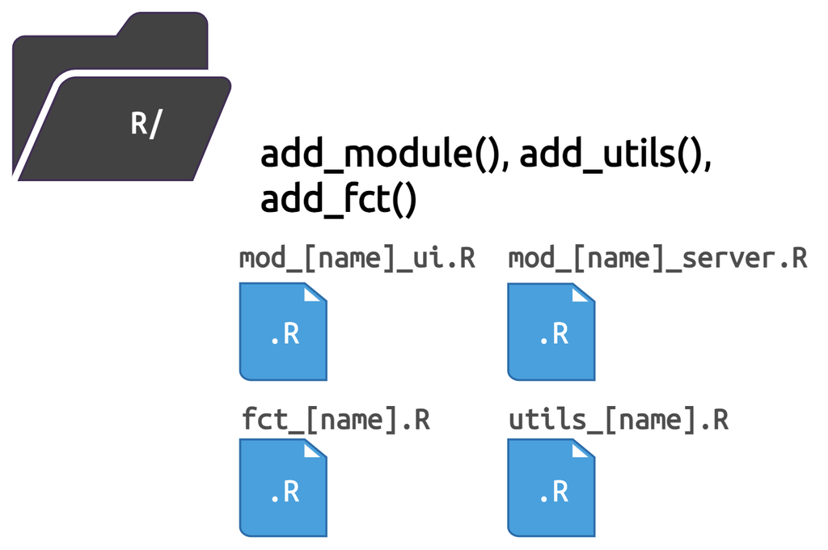

`golem::add_` functions

**Important`golem` modules and helper functions: **Highly recommend**

These functions are incredibly helpful for a variety of reasons: 1) they simplify the naming convention by automatically creating prefixes for modules (`mod_[name]_ui`/`mod_[name]_server`) and helper functions (`utils_`/`fct_`), 2) the `with_test` argument makes it easy to create an accompanying test file, which ensures you have tests for each function/module (and promotes test-driven development!).

#### `External resources`

`dev/02_dev.R` includes `golem` wrappers for including CSS, JavaScript, and SASS files to the `inst/app/www/` folder:

##### JavaScript files

You can add JavaScript to your application using the [`golem::add_js_file("script")`](https://thinkr-open.github.io/golem/reference/add_files.html) and [`golem::add_js_handler("handlers")`](https://thinkr-open.github.io/golem/reference/add_files.html) functions.

The `golem` text has an entire chapter dedicated to JavaScript (which is worth reading).

##### App styling

You can add CSS or SASS styling to your application using the [`golem::add_css_file("custom")`](https://thinkr-open.github.io/golem/reference/add_files.html) and [`golem::add_sass_file("custom")`](https://thinkr-open.github.io/golem/reference/add_files.html) functions, too.

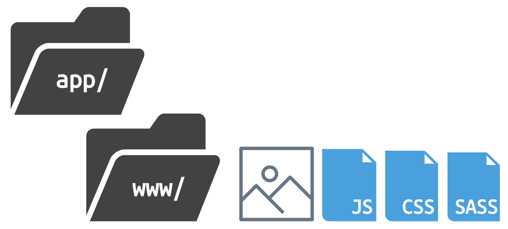

`golem` external resources

**Caution`golem` external resources: **Recommend**

It’s unlikely a production-grade shiny application only includes R code, and figuring out how to add other code files to your application can get complicated quickly. These functions are incredibly helpful (and they [work outside of a `golem` applications!](https://thinkr-open.github.io/golem/articles/b_dev.html#add-external-files)).

#### `Add internal datasets`

If you application uses data, you can add it to your application with the `usethis` functions (`use_data_raw()` or `use_data()`). I recommend reading the [data section](https://r-pkgs.org/data.html) of R packages (and [this section](https://r-pkgs.org/misc.html#sec-misc-inst) on adding data to `inst/extdata`).

[figure not shown]

`golem` app data

Locations of data in `golem` app-packages

##### `inst/extdata`

External data you’d like to make available in your package should be stored in `inst/extdata/`

This is where I’ve placed the `movies` file:

```
inst/extdata/
└── movies.RData

1 directory, 1 file
```

##### `use_data_raw()`

The `data-raw/` folder is for the *‘data-creating script’* that was used to create the version of the data in your app-package:

- I’ll create a raw data file for `movies`.

```r
usethis::use_data_raw("movies")
```

- Newly created `.R` scripts in `use_data_raw()` will have a call to `use_data()`. See below:

  ```bash
  ✔ Writing 'data-raw/movies.R'
  • Modify 'data-raw/movies.R'
  • Finish the data preparation script in 'data-raw/movies.R'
  • Use `usethis::use_data()` to add prepared data to package
  ```

##### `use_data()`

The objects created from the `.R` files in `data-raw/` are stored in the `data/` folder (and any other data you need in your app-package).

> “*store R objects and make them available to the user…in `data/`*”

For example, in `data-raw/movies.R`, I load the movies data from `inst/extdata/`, and save `movies` to the `data/` folder:

```r
## code to prepare `movies` dataset goes here
load("inst/extdata/movies.RData")
usethis::use_data(movies, overwrite = TRUE)
```

- The output is below:

  ```bash
  ✔ Saving 'movies' to 'data/movies.rda'
  • Document your data (see 'https://r-pkgs.org/data.html')
  ```

Follow [this guide](https://cran.r-project.org/web/packages/roxygen2/vignettes/rd-other.html) to document your datasets.

**show/hide movies data documentation**

```r
#' Movies dataset
#'
#' A dataset containing movie rankings from IMDB and Rotten Tomatoes. Original
#' source found [here](https://rstudio-education.github.io/shiny-course/)
#'
#' @format A data frame with 651 rows and 34 variables:
#'
#' \describe{
#'   \item{title}{movie title}
#'   \item{title_type}{title type (Documentary, Feature Film, TV, Movie)}
#'   \item{genre}{movie genre (Action & Adventure, Animation,
#'                Art House & International, Comedy, Documentary, Drama, Horror,
#'                Musical & Performing Arts, Mystery & Suspense, Other,
#'                Science Fiction & Fantasy)}
#'   \item{runtime}{length of film (in minutes)}
#'   \item{mpaa_rating}{G, NC-17, PG, PG-13, R, Unrated}
#'   \item{studio}{studio movie was filmed in}
#'   \item{thtr_rel_date}{Theatre release date}
#'   \item{thtr_rel_year}{Theatre release year}
#'   \item{thtr_rel_day}{Theatre release day}
#'   \item{dvd_rel_date}{DVD release date}
#'   \item{dvd_rel_year}{DVD release year}
#'   \item{dvd_rel_month}{DVD release month}
#'   \item{dvd_rel_day}{DVD release day}
#'   \item{imdb_rating}{IMDB rating}
#'   \item{imdb_num_votes}{IMDB number of votes}
#'   \item{critics_rating}{Critics rating}
#'   \item{critics_score}{Critics score}
#'   \item{audience_rating}{Audience rating}
#'   \item{audience_score}{Audience score}
#'   \item{best_pic_nom}{Best picture nomination?}
#'   \item{best_pic_win}{Best picture win?}
#'   \item{best_actor_win}{Best actor win?}
#'   \item{best_actress_win}{Best actrss win?}
#'   \item{best_dir_win}{Best director win?}
#'   \item{top200_box}{Top 200 box-office?}
#'   \item{director}{Film director name}
#'   \item{actor1}{Actor 1 name}
#'   \item{actor2}{Actor 2 name}
#'   \item{actor3}{Actor 3 name}
#'   \item{actor4}{Actor 4 name}
#'   \item{actor5}{Actor 5 name}
#'   \item{imdb_url}{IMDB website url}
#'   \item{rt_url}{Rotten Tomatoes website url}
#' }
"movies"
```

The `fivethirtyeight` package also has [great examples of documented datasets.](https://github.com/rudeboybert/fivethirtyeight/blob/master/R/data.R)

After loading and documenting your package, you can view structure and variable names of the `movies` data by entering `??movies` in the Console:

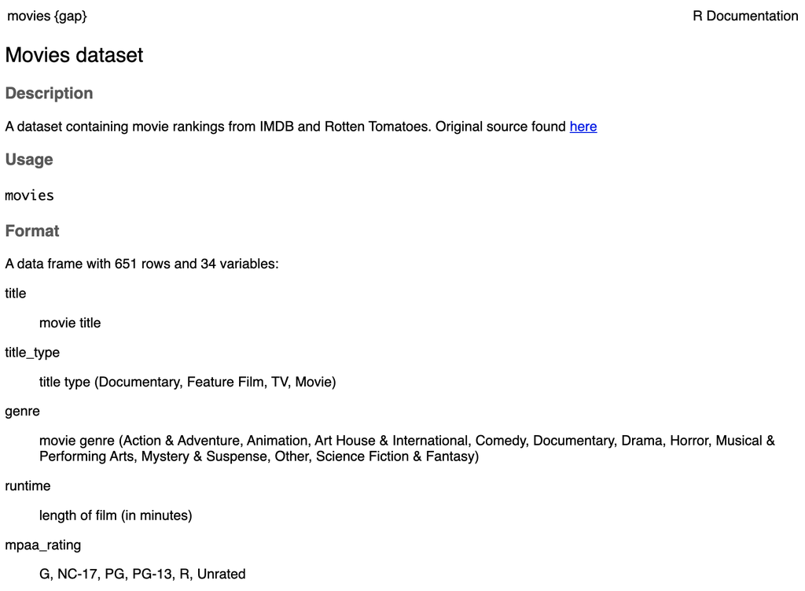

(a) `movies` data documentation

Figure 2: Documentation for `gap::movies` stored in `R/data.R`

#### `Tests`

The `tests/` folder was created in `dev/01_start.R` with [`golem::use_recommended_tests()`](https://thinkr-open.github.io/golem/reference/use_recommended.html). This function is a wrapper around `usethis::use_testthat()`, and it sets up the `tests/` folder:

```
tests
├── spelling.R
├── testthat/
└── testthat.R
```

In `dev/02_dev.R`, the [`golem::add_module()`](https://thinkr-open.github.io/golem/reference/add_module.html) and [`golem::add_utils()`/`golem::add_fct()`](https://thinkr-open.github.io/golem/reference/utils_files.html) functions also include a `with_test = TRUE` argument, which creates a test file in the `tests/` folder.

```
tests/testthat
├── test-golem-recommended.R
├── test-golem_utils_server.R
└── test-golem_utils_ui.R

1 directory, 3 files
```

These files test the functions in the files `golem_utils_ui.R` and `golem_utils_server.R`, and we can run them independently with `testthat::test_file()`

```r
test_file("tests/testthat/test-golem_utils_server.R")
```

```bash
[ FAIL 0 | WARN 0 | SKIP 0 | PASS 13 ]
```

```r
test_file("tests/testthat/test-golem_utils_ui.R")
```

```bash
[ FAIL 0 | WARN 0 | SKIP 0 | PASS 51 ]
```

#### `Documentation`

R package vignettes contain high-level, long-form documentation for your package. These R Markdown documents combine narrative text and code that describe how the ‘parts’ (functions, data, etc.) of the package behave. In app-packages, vignettes might included the following information:

For `shiny` app-packages, the following types of documentation might be included in the vignettes:

1. Introduction to the package
2. Installation guide
3. Usage examples
4. Description of the application and modules
5. Application workflow
6. Data preparation
7. Troubleshooting
8. FAQs
9. Advanced usage
10. Details on functions and datasets
11. References and Contact information

To create a new vignette, run `usethis::use_vignette("NAME OF VIGNETTE")`:

```r
usethis::use_vignette("gap")
```

```bash
✔ Setting active project to '/Users/mjfrigaard/projects/gap'
✔ Adding 'knitr' to Suggests field in DESCRIPTION
✔ Adding 'rmarkdown' to Suggests field in DESCRIPTION
✔ Adding 'knitr' to VignetteBuilder
✔ Adding 'inst/doc' to '.gitignore'
✔ Creating 'vignettes/'
✔ Adding '*.html', '*.R' to 'vignettes/.gitignore'
✔ Writing 'vignettes/gap.Rmd'
• Modify 'vignettes/gap.Rmd'
```

The vignette file opens with the title matching the argument passed to `use_vignette()`. To build the vignettes in your package, run:

```r
devtools::build_vignettes()
```

**Tip`golem` package vignettes**

As described in [‘Rmd, Vignettes, and documentation first’](https://engineering-shiny.org/building-ispum-app.html#rmd-vignettes-and-documentation-first), R markdown vignettes are a perfect sandbox for building and testing shiny apps.

> ‘the good news is that when checking a package, i.e. when running `check()` from `devtools` (Wickham, Hester, and Chang 2020) or `R CMD check`, the Vignettes are going to be built, and the process will fail if at least one of the Vignettes fails to render. That way, you can use the documentation of the back-end as an extra tool for doing unit testing!’

> ‘One radical approach to the ’Rmd first’ philosophy is to write everything in an Rmd from the very beginning of your project: write the function code, their roxygen tags, their tests, etc., then move everything to the correct spot in the package infrastructure once you are happy with everything. And of course, when you need to add another feature to your app, open a new markdown and start the process of development and documentation again’

#### `Code Coverage`

Test code coverage measures the extent to which the test cases cover the possible execution paths in the package codebase–its a way to ensure that the tests are robust enough to verify that the code behaves as expected.

There are two functions/methods used to calculate code coverage in your application: `usethis::use_coverage()` and `covrpage::covrpage()`.

##### `usethis::use_coverage()`

`use_coverage()` is part of the `usethis` package and can be run interactively during development:

```r
usethis::use_coverage()
```

```
✔ Setting active project to '/Users/mjfrigaard/projects/gap'
```

##### `covrpage::covrpage()`

Install `covrpage` using the following:

```r
# install.packages("remotes")
# remotes::install_github('yonicd/covrpage',
#   force = TRUE, quiet = TRUE)
library(covrpage)
```

To use `covrpage`, run the following:

```r
covrpage::covrpage()
```

```r
covrpage::covrpage()
```

This sets up the `README` in the `tests/` folder.

```
tests/
├── README.md <- covrpage README!
├── spelling.R
├── testthat
│   ├── test-golem-recommended.R
│   ├── test-golem_utils_server.R
│   └── test-golem_utils_ui.R
└── testthat.R
```

The test coverage vignette is created with `use_covrpage_vignette()`

```r
covrpage::use_covrpage_vignette()
```

```
copying tests_and_coverage.Rmd into ./vignettes
adding inst/doc to .gitignore
adding knitr,rmarkdown to Suggests field in ./DESCRIPTION
adding VignetteBuilder: knitr to ./DESCRIPTION
```

You can view the `covrpage` for this app [here](https://github.com/mjfrigaard/gap/tree/main/tests)

#### `CI`

Continuous integration can be handled with one of the GitHub Actions functions (make sure you’re using Git). See the [`usethis` website](https://usethis.r-lib.org/reference/use_github_action.html) for more information on using GitHub Actions.

If you’re using another CI management system, the following options are available.

##### Github Actions CI

- Set up GitHub actions

  ```r
  # GitHub Actions
  usethis::use_github_action()
  ```

  ```r
  # Chose one of the three
  usethis::use_github_action_check_release()
  usethis::use_github_action_check_standard()
  usethis::use_github_action_check_full()
  ```

  ```r
  # Add action for PR
  usethis::use_github_action_pr_commands()
  ```

##### Other CI Options

- Travis CI

  ```r
  usethis::use_travis()
  usethis::use_travis_badge()
  ```

- AppVeyor

  ```r
  usethis::use_appveyor()
  usethis::use_appveyor_badge()
  ```

- Circle CI

  ```r
  usethis::use_circleci()
  usethis::use_circleci_badge()
  ```

- Jenkins

  ```r
  usethis::use_jenkins()
  ```

- GitLab CI

  ```r
  usethis::use_gitlab_ci()
  ```

### End `02_dev.R`

This concludes the `02_dev.R` file. It’s likely you’ll return to this file repeatedly for various functions during development, so I’d leave it in the `dev/` folder for future reference.

## Use

In this section, I’ll go over the functions used during application development, how to launch the application (locally, in the IDE), and the third and final `dev/` script (`dev/03_deploy.R`), which is full of options for deploying your shiny app.

### Writing code

While developing, I find the `add_*` functions are incredibly helpful (`add_module()`, `add_utils()`, and `add_fct()`). New modules functions can be created with [`golem::add_module("name")`](https://thinkr-open.github.io/golem/reference/add_module.html) along with their tests and utility functions.

```r
add_module(name = "plot", utils = "server", with_test = TRUE)
```

```bash
✔ File created at R/mod_plot.R
✔ File created at R/mod_plot_utils_server.R
✔ File created at tests/testthat/test-mod_plot.R
```

- The functions added to the `R/` folder include [`@noRd`](https://style.tidyverse.org/documentation.html#internal-functions) by default (which must be removed create the `.Rd` files in the `man/` folder)

  ```r
  # UI module template -------------------
  #' test UI Function
  #'
  #' @description A shiny Module.
  #'
  #' @param id,input,output,session Internal parameters for {shiny}.
  #'
  #' @noRd <- this one!
  #'
  #' @importFrom shiny NS tagList
  # server module template ---------------
  #' test Server Functions
  #'
  #' @noRd <- and this one!
  ```

- UI module functions end with a `_ui` suffix:

  **show/hide mod_plot_ui()**

  ```r
  #' plot UI Function
  #'
  #' @param id
  #'
  #' @return shiny UI module
  #' @export mod_plot_ui
  #'
  #' @importFrom shiny NS tagList tags
  #' @importFrom shiny plotOutput verbatimTextOutput
  mod_plot_ui <- function(id) {
    ns <- shiny::NS(id)
    shiny::tagList(
      shiny::tags$br(),
      shiny::tags$blockquote(
        shiny::tags$em(
          shiny::tags$h6(
            "The code for this application comes from the ",
            shiny::tags$a("Building web applications with Shiny",
              href = "https://rstudio-education.github.io/shiny-course/"
            ),
            "tutorial"
          )
        )
      ),
      shiny::plotOutput(outputId = ns("scatterplot"))
    )
  }
  ```

- Server module functions end with a `_server` suffix:

  **show/hide mod_plot_server()**

  ```r
  #' plot Server Functions
  #'
  #' @param id module id
  #' @param var_inputs inputs from mod_var_input
  #'
  #' @return shiny server module
  #' @export mod_plot_server
  #'
  #' @importFrom shiny NS moduleServer reactive
  #' @importFrom tools toTitleCase
  #' @importFrom shiny renderPlot
  #' @importFrom stringr str_replace_all
  #' @importFrom ggplot2 labs theme_minimal theme
  mod_plot_server <- function(id, var_inputs) {
    shiny::moduleServer(id, function(input, output, session) {
      movies <- gap::movies

      inputs <- shiny::reactive({
        plot_title <- tools::toTitleCase(var_inputs$plot_title())
        list(
          x = var_inputs$x(),
          y = var_inputs$y(),
          z = var_inputs$z(),
          alpha = var_inputs$alpha(),
          size = var_inputs$size(),
          plot_title = plot_title
        )
      })

      output$scatterplot <- shiny::renderPlot({
        plot <- point_plot(
          df = movies,
          x_var = inputs()$x,
          y_var = inputs()$y,
          col_var = inputs()$z,
          alpha_var = inputs()$alpha,
          size_var = inputs()$size
        )
        plot +
          ggplot2::labs(
            title = inputs()$plot_title,
            x = stringr::str_replace_all(tools::toTitleCase(inputs()$x), "_", " "),
            y = stringr::str_replace_all(tools::toTitleCase(inputs()$y), "_", " ")
          ) +
          ggplot2::theme_minimal() +
          ggplot2::theme(legend.position = "bottom")
      })
    })
  }

  ## To be copied in the UI
  # mod_plot_ui("plot_1")

  ## To be copied in the server
  # mod_plot_server("plot_1")
  ```

See the utility function and other module in the `gap` app-package on GitHub below:

1. [`R/mod_var.R`](https://github.com/mjfrigaard/gap/blob/main/R/mod_var.R)
2. [`R/mod_plot_utils_server.R`](https://github.com/mjfrigaard/gap/blob/main/R/mod_plot_utils_server.R)
- Include tests for new modules and functions using the `with_test = TRUE` argument

  ```bash
  tests/testthat/
              ├── _snaps
              ├── test-golem-recommended.R
              ├── test-golem_utils_server.R
              ├── test-golem_utils_ui.R
              ├── test-mod_plot.R
              ├── test-mod_plot_utils_server.R
              └── test-mod_var_input.R

  2 directories, 6 files
  ```

**TipModule names: **tip**

Including `mod` in the name of module scripts and functions makes it easier to separate them from other functions in my package namespace, if I’m using tab-completion, or if I’m searching for a particular file using `Ctrl` + `.`:

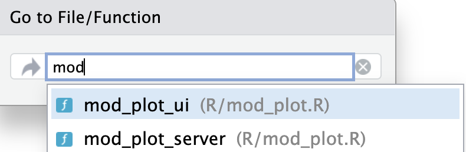

Figure 3: **Go to File/Function** in RStudio

The updated `covrpage` report is available [here](https://github.com/mjfrigaard/gap/tree/main/tests)

### Adding resources

If I want to include other files (like images), I can add these files to `inst/app/www/`,

#### `inst/app/www`

```
# add icon
inst/app
      └── www/
           └── shiny.png
```

Then I can include the path in the UI (see example below):

```r
# add icon
shiny::tags$img(src = "www/shiny.png")
```

#### `addResourcePath()`

If I wanted to include images in their own folder (like `images/`), I can use `golem::addResourcePath()` to add the name of the sub-folder to `inst/app/`

```r
# add icon
golem::add_resource_path(
          prefix = 'images',
          directoryPath = system.file('app/images',
                          package = 'gap'))
```

Now I can add the image file to the `inst/app/www/images/` folder and include the following code in the UI:

```r
# add icon
shiny::tags$img(src = "www/images/golem-hex.png")
```

- In `R/app_ui.R`, the `app_ui()` function contains the UI layout functions (`fluidPage()`, `sidebarLayout()`, etc.), and a call to `golem_add_external_resources()`:

  **show/hide app_ui()**

  ```r
  #' The application User-Interface
  #'
  #' @param request Internal parameter for `{shiny}`.
  #'     DO NOT REMOVE.
  #' @import shiny
  #' @keywords internal
  app_ui <- function(request) {
    shiny::tagList(
      # Leave this function for adding external resources
      golem_add_external_resources(),
      # Your application UI logic
      shiny::fluidPage(
        shiny::tags$h1("gap"),
        shiny::sidebarLayout(
          shiny::sidebarPanel(
            mod_var_input_ui("vars")
          ),
          shiny::mainPanel(
            # add shiny hex in www/
            shiny::tags$img(src = "www/shiny.png"),
            mod_plot_ui("plot"),
            # add golem hex (in www/images/)
            shiny::fluidRow(
              shiny::tags$em(shiny::tags$h4(
                "Brought to you by: ",
                shiny::tags$img(src = "www/images/golem-hex.png")
              ))
            )
          )
        )
      )
    )
  }
  ```

  The `golem_add_external_resources()` function is below:

  **golem_add_external_resources()**

  ```r
  # this is also included in the app_ui.R script
  golem_add_external_resources <- function() {
    add_resource_path(
      "www",
      app_sys("app/www")
    )
    tags$head(
      favicon(),
      bundle_resources(
        path = app_sys("app/www"),
        app_title = "gap"
      )
      # Add here other external resources
      # for example, you can add shinyalert::useShinyalert()
    )
  }
  ```

**Important`golem_add_external_resources()`: **Highly recommend**

`golem` app-packages take advantage of the `inst/` folder to load external resources. Using `golem_add_external_resources()` helps ensure the external resources are added to the application and loaded when the application is deployed.

### Begin `03_deploy.R`

The final step in the guided tour contains functions for deploying a new application to Posit Connect or Docker (it opens automatically after completing the `dev/02_dev.R`)

##### `Run` `checks`

These functions are part of the package development process. `devtools::check()` should be run frequently (I run it after creating a new .R file or creating a new test).

If you plan on submitting a package to CRAN, the `rhub::check_for_cran()` function will create a ‘to-do’ list of CRAN comments.

```r
## Run checks ----
## Check the package before sending to prod
devtools::check()
rhub::check_for_cran()
```

- [`devtools::check()`](https://r-pkgs.org/workflow101.html#sec-workflow101-r-cmd-check): “*It’s counter-intuitive but the key to minimizing this pain is to run `R CMD check` more often: the sooner you find a problem, the easier it is to fix*” - [R packages](https://r-pkgs.org/workflow101.html#sec-workflow101-r-cmd-check)
- The outputs from the initial `devtools::check()` are below (I’ve split it up into sections)
  - `Documenting`

  **show/hide check() Documenting output**

  ```bash
  ══ Documenting ═══════════════════════════════════════════════════════════
  ℹ Updating gap documentation
  ℹ Loading gap

  ══ Building ═════════════════════════════════════════════════════════════
  Setting env vars:
  • CFLAGS    : -Wall -pedantic -fdiagnostics-color=always
  • CXXFLAGS  : -Wall -pedantic -fdiagnostics-color=always
  • CXX11FLAGS: -Wall -pedantic -fdiagnostics-color=always
  • CXX14FLAGS: -Wall -pedantic -fdiagnostics-color=always
  • CXX17FLAGS: -Wall -pedantic -fdiagnostics-color=always
  • CXX20FLAGS: -Wall -pedantic -fdiagnostics-color=always
  ── R CMD build ──────────────────────────────────────────────────────────
  ✔  checking for file '/projects/apps/gap/DESCRIPTION' ...
  ─  preparing ‘gap’: (561ms)
  ✔  checking DESCRIPTION meta-information ...
  ─  installing the package to build vignettes
  ✔  creating vignettes (5.6s)
  ─  excluding invalid files
     Subdirectory 'R' contains invalid file names:
       ‘_disable_autoload.R’
  ─  checking for LF line-endings in source and make files and shell scripts
  ─  checking for empty or unneeded directories
  ─  building ‘gap_0.0.0.9000.tar.gz’
  ```

  - `Checking`

  **show/hide check() Checking output**

  ```bash
  ══ Checking ══════════════════════════════════════════════════════════════
  Setting env vars:
  • _R_CHECK_CRAN_INCOMING_REMOTE_               : FALSE
  • _R_CHECK_CRAN_INCOMING_                      : FALSE
  • _R_CHECK_FORCE_SUGGESTS_                     : FALSE
  • _R_CHECK_PACKAGES_USED_IGNORE_UNUSED_IMPORTS_: FALSE
  • NOT_CRAN                                     : true
  ── R CMD check ───────────────────────────────────────────────────────────
  ─  using log directory ‘/private/var/folders/0x/x5wkbhmx0k74tncn9swz7xpr0000gn/T/RtmpYiEbLJ/file75936b43aefb/gap.Rcheck’
  ─  using R version 4.2.3 (2023-03-15)
  ─  using platform: x86_64-apple-darwin17.0 (64-bit)
  ─  using session charset: UTF-8
  ─  using options ‘--no-manual --as-cran’
  ✔  checking for file ‘gap/DESCRIPTION’
  ─  this is package ‘gap’ version ‘0.0.0.9000’
  ─  package encoding: UTF-8
  ✔  checking package namespace information
  ✔  checking package dependencies (2s)
  ✔  checking if this is a source package ...
  ✔  checking if there is a namespace
  ✔  checking for executable files (592ms)
  ✔  checking for hidden files and directories
  ✔  checking for portable file names
  ✔  checking for sufficient/correct file permissions
  ✔  checking whether package ‘gap’ can be installed (5s)
  ✔  checking installed package size
  ✔  checking package directory ...
  ✔  checking for future file timestamps ...
  ✔  checking ‘build’ directory
  ✔  checking DESCRIPTION meta-information ...
  ✔  checking top-level files ...
  ✔  checking for left-over files
  ✔  checking index information ...
  ✔  checking package subdirectories ...
  ✔  checking R files for non-ASCII characters ...
  ✔  checking R files for syntax errors ...
  ✔  checking whether the package can be loaded (1.2s)
  ✔  checking whether the package can be loaded with stated dependencies (1s)
  ✔  checking whether the package can be unloaded cleanly (998ms)
  ✔  checking whether the namespace can be loaded with stated dependencies (991ms)
  ✔  checking whether the namespace can be unloaded cleanly (1.2s)
  ✔  checking dependencies in R code (1.1s)
  ✔  checking S3 generic/method consistency (2.1s)
  ✔  checking replacement functions (1.1s)
  ✔  checking foreign function calls (1.1s)
  ✔  checking R code for possible problems (6.8s)
  ✔  checking Rd files (406ms)
  ✔  checking Rd metadata ...
  ✔  checking Rd line widths ...
  ✔  checking Rd cross-references ...
  ✔  checking for missing documentation entries (1.2s)
  W  checking for code/documentation mismatches (2.4s)
     Data codoc mismatches from documentation object 'movies':
     Variables in data frame 'movies'
       Code: actor1 actor2 actor3 actor4 actor5 audience_rating
             audience_score best_actor_win best_actress_win best_dir_win
             best_pic_nom best_pic_win critics_rating critics_score director
             dvd_rel_date dvd_rel_day dvd_rel_month dvd_rel_year genre
             imdb_num_votes imdb_rating imdb_url mpaa_rating rt_url runtime
             studio thtr_rel_date thtr_rel_day thtr_rel_month thtr_rel_year
             title title_type top200_box
       Docs: actor1 actor2 actor3 actor4 actor5 audience_rating
             audience_score best_actor_win best_actress_win best_dir_win
             best_pic_nom best_pic_win critics_rating critics_score director
             dvd_rel_date dvd_rel_day dvd_rel_month dvd_rel_year genre
             imdb_num_votes imdb_rating imdb_url mpaa_rating rt_url runtime
             studio thtr_rel_date thtr_rel_day thtr_rel_year title
             title_type top200_box

  ✔  checking Rd \usage sections (3.4s)
  ✔  checking Rd contents ...
  ✔  checking for unstated dependencies in examples ...
  ✔  checking contents of ‘data’ directory ...
  ✔  checking data for non-ASCII characters ...
  ✔  checking LazyData
  ✔  checking data for ASCII and uncompressed saves ...
  ✔  checking installed files from ‘inst/doc’
  ✔  checking files in ‘vignettes’ ...
  ✔  checking examples (2.4s)
  ✔  checking examples with --run-donttest (2.8s)
  ✔  checking for unstated dependencies in ‘tests’ ...
  ─  checking tests ...
  ```

  - `spelling.R`

  **show/hide check() spelling.R**

  ```bash
  ✔  Running ‘spelling.R’
  X  Comparing ‘spelling.Rout’ to ‘spelling.Rout.save’ ...
     6,47d5
     < Potential spelling errors:
     <   WORD                   FOUND IN
     < CONFIG                 get_golem_config.Rd:17
     < Codecov                README.md:11
     < Config                 get_golem_config.Rd:5,25
     < HTLM                   with_red_star.Rd:10
     < IMDB                   movies.Rd:27,28,45,53
     < Theatre                movies.Rd:20,21,22
     < UI                     mod_plot_ui.Rd:5,13,16
     <                        mod_var_ui.Rd:5,13
     < Ventura                tests_and_coverage.Rmd:109
     < ackage                 README.md:6
     < actrss                 movies.Rd:36
     < br                     rep_br.Rd:5,10,13,16
     <                        tests_and_coverage.Rmd:82
     < config                 app_sys.Rd:15
     <                        get_golem_config.Rd:15,20,22
     <                        tests_and_coverage.Rmd:39,89
     < covr                   tests_and_coverage.Rmd:29,116
     < covrpage               tests_and_coverage.Rmd:24,117
     < darwin                 tests_and_coverage.Rmd:108
     < enurl                  tests_and_coverage.Rmd:83
     < goelm                  title:1
     < jq                     tests_and_coverage.Rmd:81
     < jquery                 jq_hide.Rd:5,13
     < li                     tests_and_coverage.Rmd:75,77
     < macOS                  tests_and_coverage.Rmd:109
     < na                     not_in.Rd:5,15
     <                        not_na.Rd:5,13
     <                        tests_and_coverage.Rmd:69
     < reactiveValues         rv.Rd:5,13
     < reactiveValuesToList   rvtl.Rd:5,13
     < rv                     tests_and_coverage.Rmd:73
     < rvtl                   tests_and_coverage.Rmd:73
     < sys                    tests_and_coverage.Rmd:88
     < tagRemoveAttributes    tests_and_coverage.Rmd:78
     < testthat               tests_and_coverage.Rmd:49,115
     < tibble                 point_plot.Rd:10
     < ui
     tests_and_coverage.Rmd:37,41,54,74,74,75,75,76,76,77,77,78,78,79,
     79,80,80,81,
                            81,82,82,83,83,84,84,85,85,86,92,93
     < undisplay              tests_and_coverage.Rmd:79
     < ️                    tests_and_coverage.Rmd:97
  ```

  - `testthat.R`

  **show/hide check() tests and coverage**

  ```bash
  ✔  Running ‘testthat.R’ (2.9s)
  ✔  checking for unstated dependencies in vignettes ...
  ✔  checking package vignettes in ‘inst/doc’
  ✔  checking re-building of vignette outputs (1.6s)
  ✔  checking for non-standard things in the check directory
  ✔  checking for detritus in the temp directory

     See
       ‘/private/var/folders/0x/x5wkbhmx0k74tncn9swz7xpr0000gn/T/RtmpYiEbLJ/file75936b43aefb/gap.Rcheck/00check.log’
     for details.
  ```

  - `R CMD check results`

  **show/hide check() R CMD check**

  ```bash
  ── R CMD check results ──────────────────────────────────── gap 0.0.0.9000 ────
  Duration: 48.2s

  ❯ checking for code/documentation mismatches ... WARNING
    Data codoc mismatches from documentation object 'movies':
    Variables in data frame 'movies'
      Code: actor1 actor2 actor3 actor4 actor5 audience_rating
            audience_score best_actor_win best_actress_win best_dir_win
            best_pic_nom best_pic_win critics_rating critics_score director
            dvd_rel_date dvd_rel_day dvd_rel_month dvd_rel_year genre
            imdb_num_votes imdb_rating imdb_url mpaa_rating rt_url runtime
            studio thtr_rel_date thtr_rel_day thtr_rel_month thtr_rel_year
            title title_type top200_box
      Docs: actor1 actor2 actor3 actor4 actor5 audience_rating
            audience_score best_actor_win best_actress_win best_dir_win
            best_pic_nom best_pic_win critics_rating critics_score director
            dvd_rel_date dvd_rel_day dvd_rel_month dvd_rel_year genre
            imdb_num_votes imdb_rating imdb_url mpaa_rating rt_url runtime
            studio thtr_rel_date thtr_rel_day thtr_rel_year title
            title_type top200_box

  0 errors ✔ | 1 warning ✖ | 0 notes ✔
  ```

- [`rhub::check_for_cran()`](https://r-hub.github.io/rhub/): “*run `check_for_cran()` and assign the result to an object*” … “*use the `cran_summary()` method to get a message that you can copy-paste in your `cran-comments.md` file*” - [`rhub`](https://r-hub.github.io/rhub/articles/rhub.html#prepare-a-cran-submission)

**Important`devtools::check()`: **Highly recommend**

It’s easy to forget some of the development workflow steps while you’re creating an app-package–`devtools::check()` makes it easier to ensure you’re building a robust package (and app!).

##### `Local`, `CRAN` `or` `Package` `Manager`

`devtools::build()` is also a regular part of the package development process. This function will source and bundle your package (learn the differences [here](https://r-pkgs.org/structure.html#sec-installed-package)).

```r
# Deploy

## Local, CRAN or Package Manager ----
## This will build a tar.gz that can be installed locally,
## sent to CRAN, or to a package manager
devtools::build()
```

This will create a `gap_0.0.0.9000.tar.gz` file to share or submit to a package management system.

```bash
── R CMD build ───────────────────────────────────────────────────────────────
✔  checking for file ‘/projects/apps/gap/DESCRIPTION’ ...
─  preparing ‘gap’: (613ms)
✔  checking DESCRIPTION meta-information ...
─  installing the package to build vignettes
✔  creating vignettes (6.6s)
─  excluding invalid files
   Subdirectory 'R' contains invalid file names:
     ‘_disable_autoload.R’
─  checking for LF line-endings in source and make files and shell scripts
─  checking for empty or unneeded directories
─  building ‘gap_0.0.0.9000.tar.gz’

[1] "/projects/apps/gap_0.0.0.9000.tar.gz"
```

- `devtools::install()` is another common development workflow function.

##### `RStudio`

To deploy an application with RStudio (Posit) products, use of the functions below:

```r
## RStudio ----
## If you want to deploy on RStudio related platforms
golem::add_rstudioconnect_file()
golem::add_shinyappsio_file()
golem::add_shinyserver_file()
```

- [`golem::add_rstudioconnect_file()`](https://thinkr-open.github.io/golem/reference/rstudio_deploy.html)
- [`golem::add_shinyappsio_file()`](https://thinkr-open.github.io/golem/reference/rstudio_deploy.html)
- [`golem::add_shinyserver_file()`](https://thinkr-open.github.io/golem/reference/rstudio_deploy.html)

##### `Docker`

If you use Docker to deploy applications, you can use the following functions:

**show/hide docker functions**

```r
## Docker ----
## If you want to deploy via a generic Dockerfile
golem::add_dockerfile_with_renv()

## If you want to deploy to ShinyProxy
golem::add_dockerfile_with_renv_shinyproxy()
```

Read more:

- [`golem::add_dockerfile_with_renv()`](https://thinkr-open.github.io/golem/reference/dockerfiles.html)
- [`golem::add_dockerfile_with_renv_shinyproxy()`](https://thinkr-open.github.io/golem/reference/dockerfiles.html)

#### `app.R`

I’ll deploy my app using shinyapps.io, so after running `golem::add_shinyappsio_file()` I will see the following output and a new `app.R` file.

```r
golem::add_shinyappsio_file()
```

```bash
── Creating _disable_autoload.R ──────────────────────────────────
✔ Created
✔ Setting active project to '/Users/mjfrigaard/projects/gap'
✔ Adding '^app\\.R$' to '.Rbuildignore'
✔ Adding '^rsconnect$' to '.Rbuildignore'
✔ Adding 'pkgload' to Imports field in DESCRIPTION
• Refer to functions with `pkgload::fun()`
✔ File created at /Users/mjfrigaard/projects/gap/app.R
To deploy, run:
• rsconnect::deployApp()

• Note that you'll need to upload the whole package to ShinyApps.io
```

- View the `app.R` file contents below:

```r
# Launch the ShinyApp (Do not remove this comment)
# To deploy, run: rsconnect::deployApp()
# Or use the blue button on top of this file
pkgload::load_all(export_all = FALSE, helpers = FALSE, attach_testthat = FALSE)
options( "golem.app.prod" = TRUE)
gap::run_app() # add parameters here (if any)
```

**Important`app.R`: **Highly recommend**

Being able to run your application from `app.R` is helpful because it performs a few preliminary operations before launching:

- [`pkgload::load_all()`](https://search.r-project.org/CRAN/refmans/pkgload/html/load_all.html): ‘*It roughly simulates what happens when a package is installed and loaded with `library()`, without having to first install the package*’
- [`options('golem.app.prod' = TRUE)`](https://engineering-shiny.org/build-app-golem.html#using-golem-dev-functions): ‘*use functions in your back-end for development purposes, that will be ignored in production*’

#### `deployApp()`

The `rsconnect::deployApp()` function will deploy the application to the shinyapps.io site (provided you have an account).

```r
rsconnect::deployApp(appName = "gap-movies")
```

```bash
Preparing to deploy application...DONE
Uploading bundle for application: 9468261...DONE
Deploying bundle: 7466839 for application: 9468261 ...
Waiting for task: 1319021708
  building: Parsing manifest
  building: Building image: 8845318
  building: Installing system dependencies
  building: Fetching packages
  building: Building package: pkgload
  building: Building package: testthat
  building: Installing files
  building: Pushing image: 8845318
  deploying: Starting instances
  rollforward: Activating new instances
  success: Stopping old instances
Application successfully deployed to https://mjfrigaard.shinyapps.io/gap-movies/
```

**Caution`rsconnect::deployApp()`: **Recommend**

The `rsconnect::deployApp()` function is helpful for quickly deploying a shiny app-package. I provide the `appName` because `gap` is not long enough, but there are other useful arguments for deploying an app into production.

### End `03_deploy.R`

View the deployed application [here.](https://mjfrigaard.shinyapps.io/gap-movies/)

## Recap

Building an application with `golem` is *very* similar to developing an R package. The overall process remains the same: New code is placed in `R/`, external resources are placed in `inst/`, tests are stored and run from `tests/testthat/`, etc. The figure below displays how the `golem` framework works within the R package structure to create ‘production-grade shiny applications’:

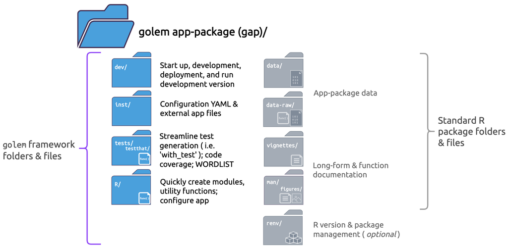

(a) `golem` app-package

Figure 4: `golem` framework overview

I didn’t cover using `renv` with this app-package, but you can read more about this in the [Using {`renv`}](https://engineering-shiny.org/build-yourself-safety-net.html#b.-using-renv) section.

[interactive chart not shown]